# Class 17: Dealing with Issues in Multiple Regression

Hughes/Fisher

# Back to checking assumptions!

In STA 363, we have been repeatedly reminding you of the underlying assumptions of the statistical models that we have been fitting, both for designed experiments and multiple regression models using observational data. We have also been feeding you, bit by bit, some remedial steps that you can take to address violations of assumptions. These are covered in great length and detail in Chapter 8 in the textbook.

So, it is not our intention here to go over how to check these things in an introductory manner, because we are past that. *The goal of this in-class presentation is to provide you with a case study to work with, to consider and attempt remedial steps in addressing assumption violations.*

It is important to keep in mind the following philosophy when addressing violations:

1. Some assumptions are more critical that others.
2. Assumptions are rarely ever *perfectly* satisfied. Rather, it is more a case of *how bad is the violation*. Keeping this in mind will help keep you from trying to “make everything perfect”.

**Order of consideration.** There is a reasonable “pecking order” in terms of checking and addressing the assumptions. Here we list the assumptions in a multiple regresion analysis in order of importance:

1. **Independence:** The errors are independent (i.e. all observations are made independent of one another).
2. **Linearity:** The structural part of the regression model is reasonably well specified.
3. **Constant Variance:** The errors have homogeneous variance.
4. **Normality:** The errors are normally distributed.
5. **Unusual observations:** Occasionally, a few observations may not fit the model well. These have the potential to dramatically alter the results, so we should check for them and investigate their validity.

### Case Study: Navy Hospitals

Data was collected from 17 U.S. Naval hospitals at various sites around the world. The government is interested in studying the relationship between monthly labor hours (`Manhours`) and average daily patient load, monthly x-ray exposures, eligible population in the area and average length of a patient’s stay, in days.

The following code chunk reads in the data to R. We also choose to remove the variable `Bed.Days` from the dataset:

```r
hospital <- read.table("navyHospitals.txt", header=TRUE)
hospital <- hospital %>% select(-Bed.Days)
head(hospital)
```

```
##   Patient.Load X.Rays Population Days Manhours
## 1        15.57   2463       18.0 4.45   566.52
## 2        44.02   2048        9.5 6.92   696.82
## 3        20.42   3940       12.8 4.28  1033.15
## 4        18.74   6505       36.7 3.90  1603.62
## 5        49.20   5723       35.7 5.50  1611.37
## 6        44.92  11520       24.0 4.60  1613.27
```

**QUESTION 1.** Think about the independence assumption in this context. In particular, can you think of any potential reasons why we might doubt the validity of independence of observations in this context?

*ANSWER: There could be some location-based dependence between some observations. If some hospitals are located near each other, they could draw from the same client pools and hence affect each other’s degree of usage (affecting variables like patient load, etc.)*

To address the next assumptions, we need to visualize the data and also fit a model to it. Use R to:

1. Generate a scatterplot matrix of all the variables (we have done this before)
2. Fit the main effects linear regression model given by

$$Manhours = \beta_0 + \beta_1(Patient.Load) + \beta_2(X.Rays) + \beta_3(Population) + \beta_4(Days) + \varepsilon$$

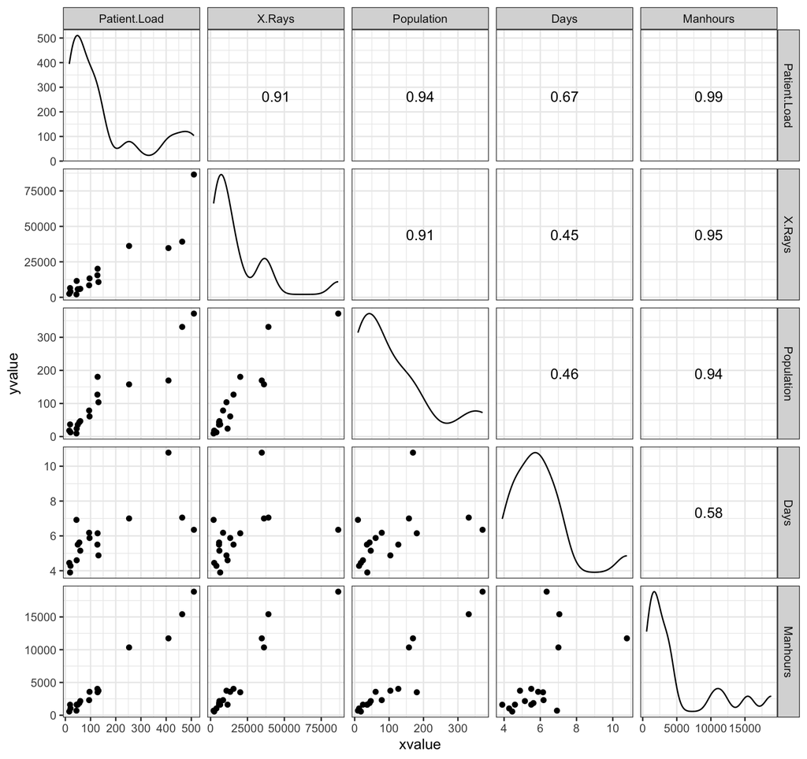

```r
ggscatmat(hospital) + theme_bw()
```

```r
hospital.fit <- lm(Manhours ~ Patient.Load + X.Rays + Population + Days, data=hospital)
```

**QUESTION 2.** Assess any associations that appear to exist between the response variable ’`Manhours` and the 4 predictors; and ALSO any associations that appear to exist solely among the 4 predictors themselves.

*Manhours appears to be strongly related to patient load, x-rays and population. It stands to reason that patient load is also correlated to population and X-rays (more population to serve -> more patients; more patients -> more x-rays).*

The next few assumptions deal with checking the residuals from a fitted model. So first, generate the residual plots from your model (we have done this many times before .. fill in the code block below):

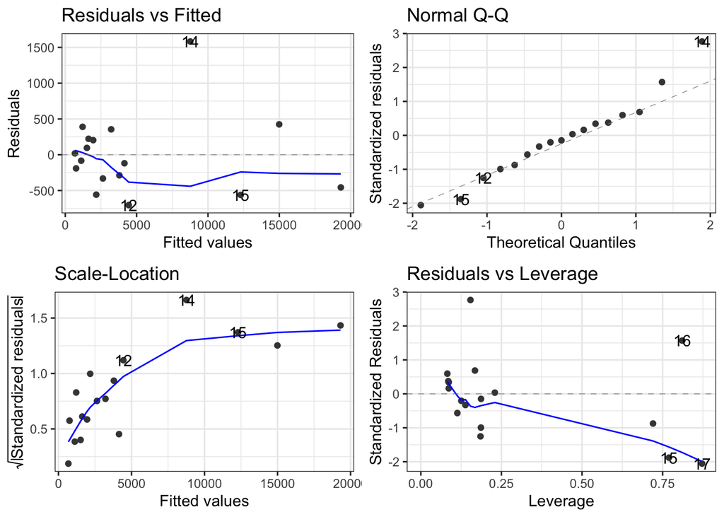

```r
autoplot(hospital.fit) + theme_bw()
```

**QUESTION 3.** Check the linearity assumption. What *would* be remedial action to take in this case, if warranted? Disucss and take remedial action if you think it is necessary.

*ANSWER: No obvious violations. No curvature of note in the residuals vs fitted plot.*

**QUESTION 4.** Check the constant variance and normality assumptions. *You should know that violations of one of these often goes hand-in-hand with violations of the other.* Take remedial action in the form of response variable transformation (Box-Cox) if you think it is necessary.

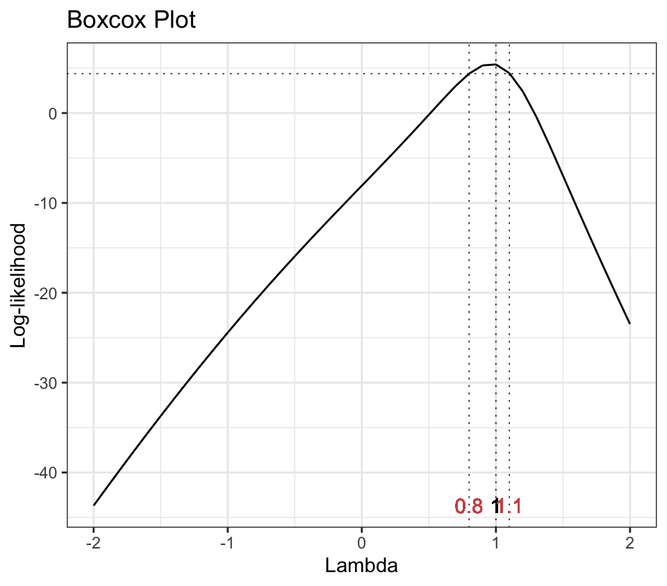

```r
gg_boxcox(hospital.fit) + theme_bw()
```

*ANSWER: There appears to be a variance issue (Scale-Location plot shows steady rise). However, no Box-Cox transformation is really warranted ($\lambda$ is approximately 1).*

**UNUSUAL OBSERVATIONS.** What we call ‘unusual observations’ in a regression analysis can be defined in a couple of different ways:

- **Outliers:** Isolated observations that are poorly predicted by the model that was fit (unusually large residual value)
- **High Leverage Points:** Observations that individually exert large influence on the resulting fitted model

We can check for these characteristics by using the lower right plot from `autoplot()`. This displays each observation’s **standardized residual** vs. its **leverage** value.

- For outlyingness, we can employ an Empirical Rule-type argument to determine what might constitute being a potential outlier ($|standardized residual| > 3$).
- For leverage, we can compare a point’s leverage value against $2p/n$, where $p$ = the number of predictor variables in the model. But, visual checks are often enough to really identify suspected points.
- There is also a more general measure of influence called **Cook’s D** which we will cover more in the next class meeting.

**QUESTION 5.** Check the residual plots for unusual observations, and identify any suspect points by observation number.

```r
# Check for leverage threshold:
2*4/17
```

```
## [1] 0.4705882
```

*ANSWER: No outliers, but we do have a few high-leverage points (higher than the threshold of 0.47).*

**Remedial action possibilities for unusual observations**

1. Check the validity of the data value. It could just be a typographical error during data entry!
2. Investigate the origin of the data point. It might be correctly recorded, but be from a different population than the one under study. If so, removal of it is warranted from the data.
3. *You should not remove a point just because it is an outlier.* If you are convinced that there is no coding error and the point is valid, then its unusual value may be the result of some underlying variable which you have not accounted for in your model. In a case like this, options include:
   - Fit your model *twice*: once to the entire data set, and again with the suspected outlier removed. See the impact of its removal on the analysis. If there is a noticeable difference in fit, then you probably shouldn’t just drop it.
   - Keeping the point, but adding a dummy variable into the model that simply indicates this point or not. Then, its unusual individual behavior will be accounted for in your model.

Here I show you these two options. Suppose we suspect that observation #14 is an outlier.

**Here is the first approach:**

```r
# Fit main effects model to the full data:
hospital.fit1 <- lm(Manhours ~ Patient.Load + X.Rays + Population + Days, data=hospital)
summary(hospital.fit1)
```

```
##
## Call:
## lm(formula = Manhours ~ Patient.Load + X.Rays + Population +
##     Days, data = hospital)
##
## Residuals:
##     Min      1Q  Median      3Q     Max
## -703.67 -331.62  -83.29  222.79 1582.57
##
## Coefficients:
##                Estimate Std. Error t value Pr(>|t|)
## (Intercept)  2161.96174  967.87108   2.234   0.0453 *
## Patient.Load   34.28393    4.89653   7.002 1.43e-05 ***
## X.Rays          0.05669    0.02055   2.759   0.0173 *
## Population     -6.60015    5.31056  -1.243   0.2377
## Days         -440.29728  183.69646  -2.397   0.0337 *
## ---
## Signif. codes:  0 '***' 0.001 '**' 0.01 '*' 0.05 '.' 0.1 ' ' 1
##
## Residual standard error: 622.1 on 12 degrees of freedom
## Multiple R-squared:  0.9906, Adjusted R-squared:  0.9875
## F-statistic: 316.6 on 4 and 12 DF,  p-value: 4.752e-12
```

```r
# Fit main effects model to the data with observation #14 removed:
hospital.fit2 <- lm(Manhours ~ Patient.Load + X.Rays + Population + Days, data=hospital[-14,])
summary(hospital.fit2)
```

```
##
## Call:
## lm(formula = Manhours ~ Patient.Load + X.Rays + Population +
##     Days, data = hospital[-14, ])
##
## Residuals:
##     Min      1Q  Median      3Q     Max
## -753.93 -204.53  -18.41  257.13  500.19
##
## Coefficients:
##                Estimate Std. Error t value Pr(>|t|)
## (Intercept)  2448.33608  612.16925   3.999  0.00209 **
## Patient.Load   35.26479    3.08751  11.422 1.93e-07 ***
## X.Rays          0.04174    0.01336   3.124  0.00969 **
## Population     -5.33488    3.35219  -1.591  0.13981
## Days         -508.97925  116.57791  -4.366  0.00113 **
## ---
## Signif. codes:  0 '***' 0.001 '**' 0.01 '*' 0.05 '.' 0.1 ' ' 1
##
## Residual standard error: 391.2 on 11 degrees of freedom
## Multiple R-squared:  0.9964, Adjusted R-squared:  0.9951
## F-statistic: 755.3 on 4 and 11 DF,  p-value: 2.452e-13
```

The model’s $\beta$-coefficient estimates changed considerably when removing the “outlier”, and the residual standard error dropped from 622.1 to 391.2! If this is a valid data point, then it shouldn’t be removed because the act of removing it changes the quality of the model considerably.

**The second approach** would be to create a dummy varibale to uniquely identify this individual hospital, and build its unique effect into the model. I do this below, creating a dummy variable named `Hospital14` using `mutate()`:

```r
hospital <- hospital %>%
  mutate(Hospital14 = (row_number()==14))
hospital       # look at the resulting dataset
```

```
##    Patient.Load X.Rays Population  Days Manhours Hospital14
## 1         15.57   2463       18.0  4.45   566.52      FALSE
## 2         44.02   2048        9.5  6.92   696.82      FALSE
## 3         20.42   3940       12.8  4.28  1033.15      FALSE
## 4         18.74   6505       36.7  3.90  1603.62      FALSE
## 5         49.20   5723       35.7  5.50  1611.37      FALSE
## 6         44.92  11520       24.0  4.60  1613.27      FALSE
## 7         55.48   5779       43.3  5.62  1854.17      FALSE
## 8         59.28   5969       46.7  5.15  2160.55      FALSE
## 9         94.39   8461       78.7  6.18  2305.58      FALSE
## 10       128.02  20106      180.5  6.15  3503.93      FALSE
## 11        96.00  13313       60.9  5.88  3571.89      FALSE
## 12       131.42  10771      103.7  4.88  3741.40      FALSE
## 13       127.21  15543      126.8  5.50  4026.52      FALSE
## 14       252.90  36194      157.7  7.00 10343.81       TRUE
## 15       409.20  34703      169.4 10.78 11732.17      FALSE
## 16       463.70  39204      331.4  7.05 15414.94      FALSE
## 17       510.22  86533      371.6  6.35 18854.45      FALSE
```

Now fit the model with the new dummy variable `Hospital14`:

```r
hospital.fit3 <- lm(Manhours ~ Patient.Load + X.Rays + Population + Days + Hospital14, data=hospital)
summary(hospital.fit3)
```

```
##
## Call:
## lm(formula = Manhours ~ Patient.Load + X.Rays + Population +
##     Days + Hospital14, data = hospital)
##
## Residuals:
##    Min     1Q Median     3Q    Max
## -753.9 -204.4    0.0  243.0  500.2
##
## Coefficients:
##                  Estimate Std. Error t value Pr(>|t|)
## (Intercept)    2448.33608  612.16925   3.999  0.00209 **
## Patient.Load     35.26479    3.08751  11.422 1.93e-07 ***
## X.Rays            0.04174    0.01336   3.124  0.00969 **
## Population       -5.33488    3.35219  -1.591  0.13981
## Days           -508.97925  116.57791  -4.366  0.00113 **
## Hospital14TRUE 1870.56494  425.34824   4.398  0.00107 **
## ---
## Signif. codes:  0 '***' 0.001 '**' 0.01 '*' 0.05 '.' 0.1 ' ' 1
##
## Residual standard error: 391.2 on 11 degrees of freedom
## Multiple R-squared:  0.9966, Adjusted R-squared:  0.995
## F-statistic: 644.2 on 5 and 11 DF,  p-value: 3.493e-13
```

Now we compare the performance of these three models:

$$\begin{array}{ccc}
\hline
\ & \textbf{Full data} & \textbf{Outlier removed} & \textbf{Full data w/dummy var} \\
\hline
{R^2_{adj}}\ & 0.9875 & 0.9951 & 0.9950 \\
Residual SE\ & 622.1 & 391.2 & 391.2 \\
\hline
\end{array}$$

We can also see that all the model $\beta$-coefficient estimates **are the same** between Model 2 (Hospital 14 removed) and Model 3 (all hospitals included, but a dummy variable added to the model to distinguish Hospital 14 from the others) for all predictors they have in common!

**OPEN QUESTION**. Provide an interpretation of the $\beta$-coefficient estimate for `Hospital14TRUE`.

*ANSWER: Regardless of any other hospital-specific predictor being considered, we estimate an aggregate increase of 1870 manhours for this specific hospital.*

### Multicollinearity and ways to deal with it

Multicollinearity (MC) is a condition when there are interrelationships (correlations) of substantial strength **among the predictor variables** in a regression. This creates porblems in interpreting the impact or significance of individual predictors on the response variable. Since this is obviously one of the main uses of regression analysis, it can be a serious issue impacting the usefulness of a model.

Before we address some strategies, first note the following:

- MC has *nothing* to do with the response variable $Y$ … it is solely a predictor issue.
- Serious MC impacts your ability to assess the contribution of individual predictors. It does **not** affect “whole-model” assessments like the overall $F$-test, $R^2$, residual standard errors, or quality of prediction of the response.

**Checking for MC.** There are a few clues you can look for to see if you have a multicollinearity problem. They are:

1. **Seeing strong pairwise correlations between predictors in your EDA scatterplot matrix.** It should be noted that MC can arise from more complex correlations than pairwise ones, so this check is not the best overall check for MC.
2. **Model Weirdness.** If you see things like a significant whole model $F$-test result, but *none* of the individual model term tests are significant, you might have strong MC. Another clue is $\beta$-coefficient estimates that are different in sign than what common sense or the EDA would predict. (Check out the coefficient estimate for `Population` … does that make any sense??)
3. **VIF**. Variance Inflation Factors are the best check for MC. There is a VIF for each predictor, and it is obtained by basicially seeing how well you can predict a given predictor from the *other* predictors in the model. $VIF > 10$ for a predictor is usually a red flag.

**QUESTION 6.** By looking at the scatterplot matrix, which predictor variables do you suspect will have strong MC in the Navy Hospitals problem?

*ANSWER: Patient load, X-rays and population (as noted earlier).*

VIFs are available in R using the `car` package. Here, I get them for Model 3 above:

```r
library(car)
vif(hospital.fit3)
```

```
## Patient.Load       X.Rays   Population         Days   Hospital14
##    25.841483     8.449453    13.689192     3.564714     1.112454
```

`Patient.Load` and `Population` are highly collinear here.

**Strategies for dealing with MC.** There are a few simple things you can try (and there are more sophisticated strategies too, but they are beyond the scope of this course). They are:

1. **Standardize all of your quantitative variables.** This can sometimes reduce the impact of MC. Basically, you re-express all the numeric variables in the model as *z-scores* by subtracting their mean and dividing by their standard deviation.
   - This can be done in R using the `scale` function. **Do not standardized any categroical or dummy variables!**
   - This doesn’t always work, but it is worth a try.
   - One nice by-product of standardizing your variables is that the relative impact of the predictors can now be compared directly between themselves, because standardizing removes the effect of different units of measurement on different predictors.
2. **Remove a predictor (or predictors) that induce the MC.** Pretty simple, but you should explore model options if doing this.

Here I show you standardizing the variables using `mutate_at()` and `scale` to see the result on the regression. We also recheck the VIFs:

```r
stdized.hospital <- hospital %>%
  mutate_at(vars(Manhours,Patient.Load,X.Rays,Population,Days), scale)
head(stdized.hospital)
```

```
##   Patient.Load     X.Rays Population       Days   Manhours Hospital14
## 1   -0.8240627 -0.7378585 -0.8181033 -0.9112772 -0.7934418      FALSE
## 2   -0.6473969 -0.7573621 -0.8968404  0.6479946 -0.7700088      FALSE
## 3   -0.7939457 -0.6684445 -0.8662719 -1.0185955 -0.7095236      FALSE
## 4   -0.8043779 -0.5478981 -0.6448816 -1.2584834 -0.6069310      FALSE
## 5   -0.6152307 -0.5846494 -0.6541448 -0.2484289 -0.6055372      FALSE
## 6   -0.6418082 -0.3122098 -0.7625241 -0.8165846 -0.6051955      FALSE
```

```r
hospital.fit4 <- lm(Manhours ~ Patient.Load + X.Rays + Population + Days + Hospital14, data=stdized.hospital)
vif(hospital.fit4)
```

```
## Patient.Load       X.Rays   Population         Days   Hospital14
##    25.841483     8.449453    13.689192     3.564714     1.112454
```

Wow, standardizing didn’t help a bit!! OK, so we’ll try some variable deletion instead.

Fit a regression model using all the predictors *except* `Population`. Find the VIFs, and check adjusted $R^2$ and the residual standard error.

```r
hospital.fit5 <- lm(Manhours ~ Patient.Load + X.Rays + Days + Hospital14, data=hospital)
vif(hospital.fit5)
```

```
## Patient.Load       X.Rays         Days   Hospital14
##    11.799408     8.269674     2.612697     1.104260
```

```r
summary(hospital.fit5)
```

```
##
## Call:
## lm(formula = Manhours ~ Patient.Load + X.Rays + Days + Hospital14,
##     data = hospital)
##
## Residuals:
##     Min      1Q  Median      3Q     Max
## -723.36 -233.26   83.66  233.88  542.81
##
## Coefficients:
##                  Estimate Std. Error t value Pr(>|t|)
## (Intercept)    1906.07114  540.08243   3.529  0.00415 **
## Patient.Load     31.64269    2.21555  14.282  6.8e-09 ***
## X.Rays            0.03863    0.01404   2.752  0.01753 *
## Days           -413.10046  105.98658  -3.898  0.00212 **
## Hospital14TRUE 1928.66372  450.03010   4.286  0.00106 **
## ---
## Signif. codes:  0 '***' 0.001 '**' 0.01 '*' 0.05 '.' 0.1 ' ' 1
##
## Residual standard error: 415.5 on 12 degrees of freedom
## Multiple R-squared:  0.9958, Adjusted R-squared:  0.9944
## F-statistic: 713.5 on 4 and 12 DF,  p-value: 3.758e-14
```

There is still some multicollinearity present due to `Patient.Load` ($VIF = 11.79$) and to some extent, `X.Rays`. While the adjusted $R^2$ is still very high, the residual standard error has suffered a bit from the previous models we fit (now $415.5$). There may be improvements that can still be done.

**Remember:** Multicollinearity is *only* a problem when you are trying to interpret the magnitude and/or significance of **individual predictors** on the response. As you see in this example, removing predictors to try to break up multicollinearity can have a deterimental effect on whole model performance (e.g. less precise predictive power).